# Elevational and seasonal patterns of butterflies and hawkmoths in plant-pollinator networks in tropical rainforests of Mount Cameroon | Scientific Reports

Elevational and seasonal patterns of butterflies and hawkmoths in plant-pollinator networks in tropical rainforests of Mount Cameroon

[Download PDF](https://www.nature.com/articles/s41598-021-89012-x.pdf)

- Article
- Open Access
- Published: 06 May 2021

# Elevational and seasonal patterns of butterflies and hawkmoths in plant-pollinator networks in tropical rainforests of Mount Cameroon

- Jan E. J. Mertens,
- Lucas Brisson<sup>,</sup>,
- Štěpán Janeček,
- Yannick Klomberg,
- Vincent Maicher<sup>,,</sup>,
- Szabolcs Sáfián<sup>,</sup>,
- Sylvain Delabye<sup>,,</sup>,
- Pavel Potocký,
- Ishmeal N. Kobe,
- Tomasz Pyrcz &
- Robert Tropek<sup>,</sup>

[*Scientific Reports*](https://www.nature.com/srep) **volume 11**, Article number: 9710 (2021) Cite this article

## Abstract

Butterflies and moths are conspicuous flower visitors but their role in plant-pollinator interactions has rarely been quantified, especially in tropical rainforests. Moreover, we have virtually no knowledge of environmental factors affecting the role of lepidopterans in pollination networks. We videorecorded flower-visiting butterflies and hawkmoths on 212 plant species (> 26,000 recorded hrs) along the complete elevational gradient of rainforests on Mount Cameroon in dry and wet seasons. Altogether, we recorded 734 flower visits by 80 butterfly and 27 hawkmoth species, representing only ~ 4% of all flower visits. Although lepidopterans visited flowers of only a third of the plant species, they appeared to be key visitors for several plants. Lepidopterans visited flowers most frequently at mid-elevations and dry season, mirroring their local elevational patterns of diversity. Characteristics of interaction networks showed no apparent elevational or seasonal patterns, probably because of the high specialisation of all networks. Significant non-linear changes of proboscis and forewing lengths were found along elevation. A positive relationship between the lengths of proboscis of hesperiid butterflies and tube of visited flowers was detected. Differences in floral preferences were found between sphingids and butterflies, revealing the importance of nectar production, floral size and shape for sphingids, and floral colour for butterflies. The revealed trait-matching and floral preferences confirmed their potential to drive floral evolution in tropical ecosystems.

## Introduction

Recently, pollination research has shifted from detailed studies of single pollination systems to network approaches. Nevertheless, most of the complex studies of individual pollinator groups’ role in plant-pollinator networks have focused on bees or hoverflies<sup>1,2</sup>, whilst the other flower visitors have often been excluded or side-lined. Although some less abundant groups play important roles in pollination systems, as secondary pollinators, nectar thieves and competitors, or even as key pollinators of specialised plants<sup>3,4,5,6,7</sup>, their importance in plant-pollinator networks remains understudied, especially in tropical forests.

Compared to bees and flies, butterflies and hawkmoths represent minor pollinators in probably all terrestrial ecosystems<sup>3,6</sup>. Both groups are often regarded as generalised nectar feeders visiting all available nectar-rich flowers<sup>8,9</sup>. Even hawkmoths, considered as efficient pollinators strongly affecting floral evolution since Darwin<sup>10</sup>, were recently revealed as opportunistic nectar thieves of many flowers<sup>11,12</sup>. However, some butterflies<sup>5,13,14</sup> and moths<sup>7,9,15,16</sup> are key pollinators of specialised plants.

Individual lepidopteran groups differ in their morphological and behavioural adaptations to pollination. Among butterflies, papilionids, pierids, and some groups of nymphalids and hesperiids use their long proboscis to feed on nectar from deep flowers, whilst many lycaenids, riodinids, and some smaller clades within the mentioned families bear small proboscis unable to reach nectar in specialised flowers<sup>17,18</sup>. In moths, besides the highly specialised long-proboscid groups such as most sphingids and noctuids, adults of many groups have dysfunctional or even no proboscis<sup>8</sup>. Such differences hamper any attempts at quantifying the general pollination role of lepidopterans.

Plants also differ in their adaptation to butterfly or moth pollination. The pollination syndrome hypothesis<sup>19</sup> expects some plants to evolve certain traits to attract the two groups. Psychophily hypothesises the adaptation for butterfly-pollination, whilst sphingophily defines hawkmoth-pollinated flowers distinguishing them from phalaenophilous plants pollinated by any other moths<sup>8,19</sup>. Consistently, butterflies and hawkmoths should prefer large conspicuous flowers or inflorescences<sup>13,20</sup>. Nocturnal hawkmoths rely comparably on colour and scent when foraging, often preferring light colours (such as white or cream) better distinguishable in the dark, and strong sweet scents<sup>21,22</sup>. This is in contrast with butterflies typically preferring bright flower colours, such as red or orange, above scent<sup>23</sup>, although sweet and fruity scents were also included into psychophily<sup>8</sup>. Nevertheless, the colour preference strongly varies among butterfly families and species<sup>24,25</sup>. Their size and proboscis length also influence flower preferences<sup>18</sup>. Small short-proboscid lycaenids avoid long-tubed flowers and visit small solitary flowers, long-proboscid papilionids or pierids, often larger and more energy-demanding, prefer massed nectar-rich flowers and inflorescences<sup>17,18</sup>. Long-proboscid hawkmoths can visit both long and short tubed flowers<sup>9</sup>.

Elevation and seasonality, representing various environmental and ecological gradients, influence patterns in biotic interactions<sup>26,27</sup>. The role, relative proportions in communities, and specific adaptations of pollinator groups may shift under differing environmental conditions, such as temperature, solar radiation, and precipitation<sup>27,28</sup>. Unfortunately, neither elevational nor seasonal patterns of the tropical lepidopteran role in pollination networks have been studied, except for a few case studies of individual plant species<sup>5</sup>. However, we can expect correlations of their role in networks with their general diversity patterns. We are not aware of any community-wide studies on characteristics of these lepidopteran-plant pollination networks in any tropical area.

Our study focuses on flower-visiting butterflies and hawkmoths, the two relatively minor groups of pollinators often overlooked in network studies, yet easily identifiable. The primary Afrotropical rainforests covering Mount Cameroon from nearly sea level to the natural timberline (ca. 2100–2300 m a.s.l. on the studied southwestern slope) offer a unique elevational gradient, with distinct dry and wet seasons. Based on rich community-wide datasets sampled along the elevational gradient and during the two seasons (Table 1), we set the following aims: (1) To evaluate the role of flower-visiting butterflies and hawkmoths in plant-pollinator networks and understand how elevation and seasonality affect their relative importance in pollination communities. (2) To analyse the elevational and seasonal changes in the structure of the pollination networks, with a specific focus on specialisation. (3) To assess butterfly and hawkmoth preferences to floral traits, as well as to test potential trait-matching between flowers and their visitors. (4) To test the potential relationship between proboscis length and specialisation of butterflies and moths in flower foraging. We hypothesise that butterflies and hawkmoths represent only a small proportion of the flower-visiting communities, although we expect their importance can be higher in lowlands and in the dry season where and when both groups are more abundant and diverse on Mount Cameroon<sup>29,30</sup>. We also expect higher specialisation in communities with more flower-visiting lepidopteran species, following MacArthur’s hypothesis on the positive relationship of niche breadth to species richness<sup>31</sup>. We expect both groups to be important pollinators of some specialised plants. We hypothesise preferences to some traits previously included in the psychophilous and sphingophilous syndromes, although we expect some predicted traits to be less important. We also expect substantial differences in the mentioned aims and hypotheses among lepidopteran families.

[Full size table](https://www.nature.com/articles/s41598-021-89012-x/tables/1)

## Results

Altogether, our comprehensive checklist of species at seven studied elevations (from 30 to 2200 m a.s.l; Table 1) comprised from 431 butterfly and 40 sphingid species (Table 1; Fig. 1a; Supplementary Table S1). Nymphalids represented the most species across the gradient, followed by lycaenids in the lowest elevations and hesperiids at the mid-elevations (650–1450 m a.s.l.; Supplementary Table S2). Species richness of all lepidopterans and lycaenids showed a gradual decrease along elevation, whilst sphingids peaked at 350 m a.s.l. (Fig. 1a). All other butterflies showed the low plateau pattern (sensu McCain and Grytnes<sup>32</sup>; Fig. 1a).

**Figure 1**

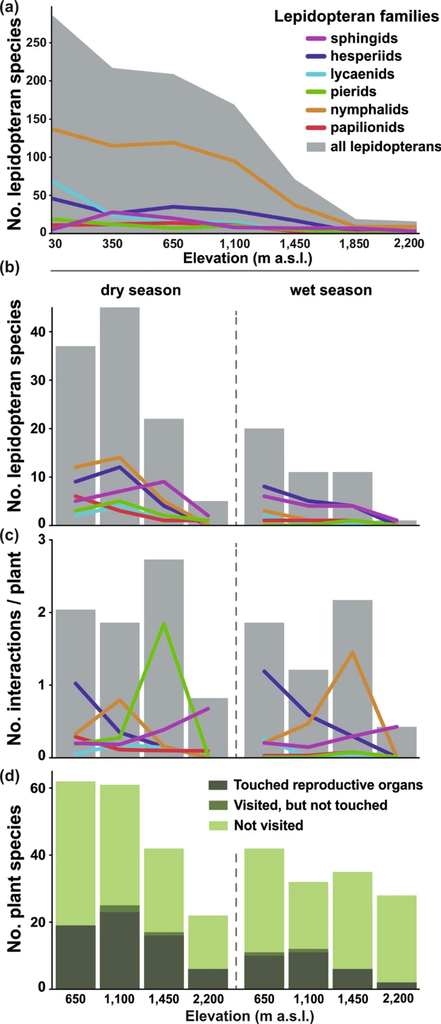

Overview of (**a**) lepidopteran species richness along the elevational gradient of Mount Cameroon, (**b**) total number of flower-visiting lepidopteran species at each elevation and season, (**c**) interaction frequency per plant and 24hrs, and (**d**) numbers of plant species whose reproductive organs were touched or untouched during lepidopteran visits, and which were not visited by any lepidopterans. Grey shading in (**a**)–(**c**) denotes the sum of all lepidopteran taxa; coloured lines represent particular families.

[Full size image](https://www.nature.com/articles/s41598-021-89012-x/figures/1)

Our intensive video-recording at four elevations (650, 1100, 1450, and 2200 m a.s.l.) and during dry and wet seasons (Table 1) resulted in 26,138 h (~ 2.98 years) of video footage of 1,115 individuals of 212 flowering plant species. On these video-recordings, we observed 734 individuals of 80 butterfly and 27 sphingid species visiting 71 plant species. These visits represented ~ 4% of all 18,439 flower visits recorded on the observed plants. Bees, flies, beetles, and other moths were more common flower visitors than butterflies<sup>27</sup>. Wasps, nectarivorous birds, and carpenter bees were more common visitors than sphingids, followed by cockroaches and mammals<sup>27</sup>. Still, butterflies and sphingids were among the two most common flower visitors for some plant species (Supplementary Table S3), such as *Scadoxus cinnabarinus* (Amaryllidaceae), *Distephanus biafrae* and *Melanthera scandens* (both Asteraceae), and *Cordia aurantiaca* (Boraginaceae) for butterflies; and *Anthocleista scandens* (Gentianaceae) for sphingids. From these, 700 lepidopteran visitors touched the plant reproductive organs (see Table 1 and Supplementary Table S4 for a taxonomic and spatiotemporal overview). Due to the small difference between ‘pollinators’ and ‘all visitors’ (700 and 734 interactions, respectively; Fig. 1d), we only report analyses of all interactions, i.e. the visitors’ point of view.

We recorded the highest species richness of both lepidopteran flower visitors and lepidopteran-visited plants at 1100 m a.s.l. during the dry season (Table 1; Fig. 1b). Species richness of visiting lepidopterans decreased towards the higher elevations and during the wet season; at 2200 m a.s.l. during the wet season we recorded only a single sphingid species visiting two plant species (Fig. 1b). In accordance, species richness of all flowering plants decreased towards the higher elevations and in the wet season. Yet, the highest elevation was more species-rich during wet than during the dry season. Overall, lepidopterans visited a lower proportion of flowering plant species during the wet season (wet season mean = 0.204 (± 0.114) vs. dry season mean = 0.334 (± 0.054); Fig. 1d).

The visitation frequency varied among the visitor families (Fig. 1c). Hesperiids were less frequent towards the higher elevations in both seasons. Papilionids followed such a pattern in the dry season but represented a generally small proportion of visitors in the wet season. Lycaenids were generally uncommon flower visitors with only small spatiotemporal differences. Pierids expressed a peak in frequency at 1450 m a.s.l. during the dry season (driven by *Mylothris* cf. *hilara* frequently visiting *Distephanus biafrae*). Nymphalids expressed a similar peak at 1450 m a.s.l. during the wet season (driven by *Vanessula milca* visiting *Melanthera scandens*). Finally, sphingids visited flowers more frequently towards the higher elevations in both seasons (Fig. 1c).

We found no apparent general pattern in turnover of flower-visiting lepidopterans and lepidopteran-visited plants among the studied elevations and seasons (Supplementary Fig. S1). The higher elevations shared fewer plant species with the lower elevations as well as between each other. The visitor community shared most species between 1100 and 1450 m, followed by 1450 m and 2200 m a.s.l. (Supplementary Fig. S1).

The reconstructed interaction networks among flowering plants and visiting lepidopterans (hereafter simplified to *plant-lepidopteran networks* or *networks*) decreased in size towards the higher elevations and the wet season, although the generally largest network was recorded at 1100 m a.s.l. in the dry season (Fig. 2). The trends in the network characteristics were minor or none, except NODF nestedness. Network connectance slightly increased along the elevational gradient and remained similar between seasons. Q modularity slightly decreased towards the higher elevations and during the wet season. NODF nestedness increased along elevation during the dry season and showed an opposite trend during the wet season. H<sub>2</sub>′ specialisation slightly increased along elevation during the wet season, whilst no pattern was observed during the dry season (Fig. 3a–e).

**Figure 2**

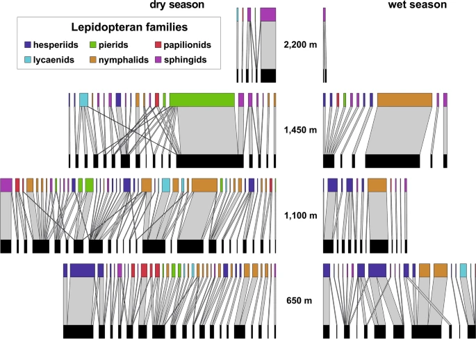

Bipartite networks of plant-lepidopteran interactions along the elevational gradient of Mount Cameroon. The upper nodes visualise flower-visiting lepidopteran species, distinguished by colour for families, whilst the lower nodes represent lepidopteran-visited plant species. The total width of each network approximates their relative size, corrected for the sampling effort (visitation frequency per 24hrs). The width of individual links (light grey) represents the relative frequency of interactions between visiting lepidopterans and visited plants within each network.

[Full size image](https://www.nature.com/articles/s41598-021-89012-x/figures/2)

**Figure 3**

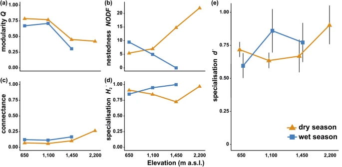

Metrics of plant-lepidopteran networks on Mount Cameroon, comparatively for each elevation and season. The symbols depict arithmetic means in all plots, whilst error bars in (e) represent 95% confidence intervals.

[Full size image](https://www.nature.com/articles/s41598-021-89012-x/figures/3)

The studied lepidopteran families did not significantly differ in *d’* specialisation (LMM, *F* = 0.865, *p* = 0.508), nor there was any significant difference in *d’* specialisation between sphingids and all butterflies (LMM, *F* = 0.287, *p* = 0.593). Model comparisons of the effects of elevation, season, and their interaction showed that the interaction effect of both factors is the most plausible descriptor of the observed patterns in *d’* specialisation (Fig. 3e; Table 2).

[Full size table](https://www.nature.com/articles/s41598-021-89012-x/tables/2)

### Patterns in lepidopteran morphological traits

Lengths of proboscis and forewing, measured in hesperiids, papilionids, and sphingids, differed significantly among the families (proboscis length: LMM, *χ*<sup>*2*</sup> = 12.15, *df* = 2, *p* = 0.002; forewing length: LMM, *χ*<sup>*2*</sup> = 31.95, *df* = 2, *p* < 0.001). Sphingids had on average the longest proboscides, followed by papilionids and hesperiids (Supplementary Table S5). Papilionids had on average the longest forewings, followed by sphingids and hesperiids (Supplementary Table S5). None of the three families showed any significant patterns in their proboscis or forewing lengths along the elevational gradient (Supplementary Table S6). However, when analysing only the flower-visiting species from our video-recordings, elevation became the most plausible descriptor of the non-linear patterns in their proboscis and forewing lengths (Table 3; Fig. 4a,b). Both traits were longest in the lowest elevation, whilst both mid-elevations were comparable. The highest elevation showed too large variability in both traits (caused by the low number of measured lepidopterans) for any reasonable interpretations. Even though only three species were measured at the highest elevation, omitting them had no substantial effect on the model parsimony (Supplementary Table S7). We found a significantly positive correlation between lepidopteran proboscis length and corolla tube length of lepidopteran-visited flowers (Fig. 4c). However, from the three lepidopteran families, the observed relationship was only significant for hesperiids when analysed separately (Fig. 4c). Neither proboscis nor forewing lengths had any significant effect on *d’* specialisation (proboscis length: Spearman, *p* = 0.38, *ρ* = 0.16; forewing length: Spearman, *p* = 0.63, *ρ* = 0.086).

[Full size table](https://www.nature.com/articles/s41598-021-89012-x/tables/3)

**Figure 4**

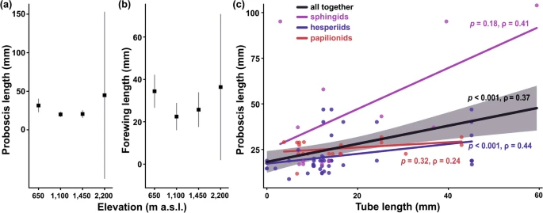

(**a**) Proboscis and (**b**) forewing lengths of flower-visiting lepidopterans on Mount Cameroon. Mean values and 95% confidence intervals are visualised. (**c**) Spearman correlations of lepidopteran proboscis length and corolla tube length of lepidopteran-visited plants. Each data point represents an interaction between a plant species and a lepidopteran species. The black line visualises correlation of all data (with grey shaded confidence intervals), whilst the coloured lines visualise correlations of individual lepidopteran families.

[Full size image](https://www.nature.com/articles/s41598-021-89012-x/figures/4)

### Lepidopteran preferences to floral traits

Finally, we analysed preferences of individual lepidopteran families to specific floral traits by multivariate RDA ordinations<sup>33</sup>. Flower-visiting lepidopterans showed significant preferences towards certain floral traits (Fig. 5). With the dataset of all flowering plants, the selected floral traits explained 25% of the variability in the visitation frequency (Fig. 5a). The focal families formed three relatively distinct groups. Sphingids preferred sugar-rich, larger and deeper flowers of purple colour. Papilionids, lycaenids, and nymphalids preferred orange flowers, whilst hesperiids and pierids did not express any apparent preferences to floral traits. These preferences were mostly consistent with the analysis including only the Lepidoptera-visited flowers (Fig. 5b), although hesperiids preferred pink actinomorphic flowers.

**Figure 5**

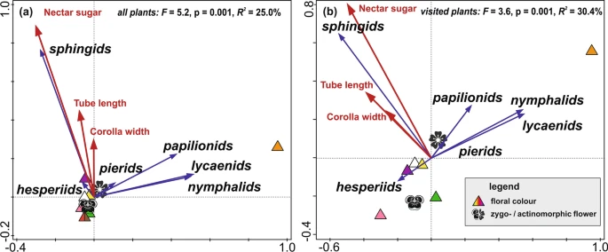

Redundancy analyses (RDA) revealing significant preferences of butterfly and sphingid families (represented by blue arrows) to floral traits (represented by red arrows and various symbols) on Mount Cameroon. The two RDA models were run for (**a**) all flowering plant species, and (**b**) the plant species visited by butterflies or moths.

[Full size image](https://www.nature.com/articles/s41598-021-89012-x/figures/5)

## Discussion

### Importance of butterflies and sphingids as pollinators

On Mount Cameroon, butterflies and sphingids did not represent the most important pollinators in the studied tropical rainforests, as they together made up ~ 4% of the flower-visiting community. Their numbers were dwarfed by flower-visiting bees, flies, and beetles, representing 44.10%, 25.71% and 11.83% of visits of all recorded plants, respectively<sup>27</sup>. The relative importance of lepidopterans in our uniquely comprehensive Afrotropical networks was even lower than in several partial networks from tropical forests of South-East Asia (e.g.<sup>34,35</sup>) and the Neotropics (e.g.<sup>36,37</sup>). In all these studies, flower visitation by lepidopterans was considerable (between 10 and 20% of all pollinators, although nocturnal visitors were ignored which could have increased the relative importance of diurnal lepidopterans), although incomparable to bees (between 40 and 55%). We are not aware of any similar study from Afrotropical forests.

Even though butterflies and sphingids visited about a third of all flowering plants in the study area, only a few plant species seemed to be primarily pollinated by these groups. Butterflies were the most common visitors of a single plant species, *Scadoxus cinnabarinus*, already known to be butterfly-pollinated<sup>5</sup>. In only a few other plant species, butterflies ranked high among all visiting groups (Supplementary Table S3). Sphingids were not the most common visitors of any recorded plant species, but they ranked second among the groups visiting *Anthocleista scandens*. Although plants within this genus have been reported as potentially pollinated by moths or sunbirds<sup>38</sup>, its widely open typical chiropterophilous flowers<sup>39</sup> do not morphologically fit to sphingophily. However, several other plants commonly visited by butterflies (e.g. *Aframomum* spp. and *Cordia aurantiaca*) and sphingids (e.g. *Mussaenda tenuiflora* and *Clerodendrum silvanum*) in our study offer morphologically specialised flowers fitting the lepidoptera-related pollination syndromes<sup>8</sup>. Their efficient pollination by lepidopterans can be expected from other studies of relative or similar plant species from other areas<sup>40,41</sup>. Several other plants commonly visited by the studied lepidopterans offered rather morphologically generalised inflorescences (e.g. *Distephanus biafrae*, *Melanthera scandens*, and *Crassocephalum montuosum*; all Asteraceae). Plants with such inflorescences have sometimes been reported as pollinated by butterflies or moths, although they were visited by rich pollinator communities and apparently did not only rely on lepidopterans<sup>42,43</sup>. Altogether, only a few plant species in our study seemed to depend on pollination by butterflies or sphingids based on the combination of their flowers’ morphology and visitation frequency. In conclusion, butterflies and sphingids seem to be relatively less relevant pollinators in Afrotropical forests.

### Seasonal patterns of lepidopteran pollination

Pollination networks of butterflies and sphingids strongly differed between the studied seasons on Mount Cameroon. This was surely influenced by a plethora of factors affecting communities of both flower-visiting lepidopterans and flowering plants. The very high inter-seasonal turnover of both butterfly and moth species composition, as well as changes in species richness and abundance, have already been reported in detail from Mount Cameroon<sup>29</sup>, as well as from other Afrotropical rainforests (e.g.<sup>44</sup>). Together with the confirmation of the high species turnover between dry and wet seasons (Supplementary Fig. S1), this study also revealed seasonal changes in lepidopteran behaviour and networks of their pollination interactions. The general decline of flower-visiting butterflies is most probably connected to the local extreme precipitation during the wet season. Adult butterflies and sphingids, like other large-winged insects, avoid the extreme rainfall on Mount Cameroon<sup>30</sup>. Simultaneously, the strong rains and related humidity also affect availability of nectar and its concentration<sup>45</sup>. The strong seasonality affects the flowering plant communities as well. Whereas many trees, usually offering large amounts of generally accessible nectar, flower during the dry season, herbs and shrubs flowering in the wet season are not able to substitute this nectar production. Our unpublished suggestions were supported by the relatively high turnover of flowering plants between the two seasons (Supplementary Fig. S1). Moreover, herbs flowering in the harsh conditions during the wet season on Mount Cameroon are often adapted to pollination by sunbirds<sup>46,47</sup>. These could be both causes and consequences of the generally lower diversity and abundance of nectarivorous lepidopterans during the wet season.

### Elevational patterns of lepidopteran pollination

Species richness of butterflies and sphingids showed the ‘low-elevation plateau with a mid-peak’ (sensu McCain and Grytnes<sup>32</sup>) in accordance with numerous studies of tropical lepidopterans<sup>30,48</sup>. The flower visitation frequencies of butterflies mirrored this result, whilst the importance of sphingids in pollination networks, both absolute and relative, increased along elevation. Because we are not aware of any studies on plant-lepidopteran pollination networks along any tropical elevational gradient for comparison, we can hardly speculate if the revealed patterns can be general. However, a study of the *Scadoxus cinnabarinus* pollination system showed peaking diversity and abundance of flower-visiting butterflies at mid-elevations of the plant range<sup>5</sup>. Besides numerous factors responsible for the generally high diversity at mid-elevations in many insect groups<sup>48,49</sup>, the patterns of plant-lepidoptera networks can be discussed in relation to the floral resources for nectarivorous butterflies and sphingids. Although we have no detailed data on the abundance of floral resources along the studied elevational gradient, the local diversity of trees linearly decreased along the gradient<sup>50</sup>. However, it remains questionable whether all flowering plants follow this pattern. The opposite trends of sphingid species richness and their importance in networks may be related to the dominance of a few highly mobile species among flower-visiting sphingids in all networks. Whilst their elevational diversity pattern was driven by numerous species with restricted elevational ranges on Mount Cameroon<sup>30</sup>, numerous identified sphingids in our networks were opportunistic long-distance vagrants (Supplementary Table S1). Considering the generally small sizes of the plant-sphingid networks and the relatively smaller elevational variability, the revealed patterns could be caused by more or less random visitation by these mobile generalists.

The prevailingly non-apparent trends in the plant-lepidopteran network characteristics can be surprising because several other studies of pollination networks along elevation revealed strong patterns, although inconsistent among the studied areas and groups<sup>1,51</sup>. Nevertheless, we are not aware of any similar study on pollination by butterflies or sphingids along any tropical elevational gradient for comparison. Therefore, we hypothesise that lepidopteran species are surprisingly specialised for visited flowers, as visible in our relatively less connected and highly specialised networks, and in the preferences for distinct floral traits. These preferences only partly change with environmental conditions<sup>27</sup>. However, as discussed above, only a minor portion of the visited flowers are specialised for lepidopteran pollination. Nevertheless, only more studies of plant-lepidopteran networks from other tropical areas can challenge such hypotheses. We admit that for the only characteristic with a strong trend, nestedness, we do not have any apparent explanation, especially because the trends strongly differed inter-seasonally.

### Traits in plant-lepidopterans networks

We found no evidence that longer proboscides or forewings of butterflies and sphingids elicited differences in the flower visitation behaviour, apart from the correlation between lengths of proboscis and floral tube of flowers visited by hesperiids. No proboscis-tube relationship has been found in other studies (e.g.<sup>9,12,52</sup>), although some studies found larger butterflies visiting larger flowers as well<sup>17,18</sup>. Nevertheless, although preferring flowers with longer tubes, the long-proboscid lepidopterans were not more specialised with respect to their food-niche breadth (relative number of visited plant species) in our study. Therefore, we assume that even these morphologically specialised lepidopteran species were looking for any available resources in longer or deeper flowers which are more likely to be unreachable by other floral visitors, rather than being specialised for a few co-evolved plant species (cf.<sup>9,12</sup>).

Although we found no significant patterns among the morphological traits of lepidopterans along elevation when analysing all captured butterflies and sphingids, the lengths of forewing and proboscis showed significant non-linear patterns when the analyses were restricted to the flower-visiting species. We expect that such patterns can be obscured by other mechanisms when analysing the complete lepidopteran community, including species with adults feeding on other resources than flowers. The increase of lepidopteran size towards the higher elevations was repeatedly reported and mostly explained by the need of a larger surface for basking in colder environments<sup>53</sup>. Nevertheless, the relatively larger bodies of lepidopterans in the lowest elevation seems surprising and difficult to explain.

## Methods

### Study area

Mount Cameroon (4095 m a.s.l.) is an active volcano in the Southwest Region, Cameroon, West/Central Africa. Primary tropical rainforests cover its southwestern flanks, where the study was performed, from lowlands (above human encroachment at ca. 300 m a.s.l.) up to the natural timberline (ca. 2200 m a.s.l.). As the mountain is located within the ‘Guinean forests of West Africa’ biodiversity hotspot, it holds an extraordinarily high biodiversity of numerous taxa, including butterflies<sup>56</sup>, hawkmoths<sup>57</sup>, and plants<sup>58</sup>. The mountain is one of the wettest places in the world and experiences distinct dry (December–February) and wet seasons (June–September)<sup>29,30</sup>. The Atlantic Ocean-facing southwestern lowlands receive large amounts of rainfall (> 12,000 mm annually), most of which occurs during the wet season (> 2500 mm monthly), and rarely any rain during the dry season<sup>30</sup>. To characterise changes in plant-pollinator interactions along elevation and season, we studied four sites on the southwestern slope at 650, 1100, 1450, and 2200 m a.s.l. The butterfly and hawkmoth species richness data includes additional sampling sites at 30, 350, and 1850 m a.s.l. (Table 1). For more details on the study sites, see Maicher et al.<sup>30</sup>.

### Study groups and their biodiversity patterns

This study focused on butterflies (Lepidoptera: Papilionoidea) and hawkmoths (Lepidoptera: Sphingidae; referred to as sphingids in the manuscript). For part of the analyses, butterflies were split up into their families (Hesperiidae, Papilionidae, Pieridae, Lycaenidae, and Nymphalidae; referred to as hesperiids, papilionids, pierids, lycaenids, and nymphalids in the manuscript). All butterflies and sphingids were represented in the *flower visitation* and *floral preferences* parts of the study. However, the effects of elevation and season on visitor size and proboscis length were analysed for papilionids, hesperiids, and sphingids only, because the other groups’ traits were not measured in the field. We actively inventoried butterflies and sphingids along the complete elevation of Mt. Cameroon (i.e. at seven elevations from 30 to 2200 m a.s.l.), using the checklist approach. For this purpose, we applied intensive hand-catching (our unpublished data) and bait-trapping (using fermented mashed bananas; data from Maicher et al.<sup>30</sup>) for butterflies, whereas we used standardised light-attraction for sphingids (data from Maicher et al.<sup>30</sup>). These data were further supplemented by a few additional species found only in the video recordings described below.

### Flower visitation

We observed all flower visitors from the video recordings either through semi-autonomic motion detection with Motion Meerkat 2.0.5<sup>59</sup> when conditions allowed, or manually through sped-up playback. We identified all butterflies and sphingids using diverse available literature and the large reference collection we have established during our work on Mt. Cameroon since 2014, and in the Gulf of Guinea Highlands since 2007. Most of the visitors were identified to species, whilst 7 morphospecies were established for butterflies and 18 for sphingids (Supplementary Table S1). In most of these cases (except 8 sphingid morphospecies), we were able to identify visiting lepidopteran to genus and to distinguish the morphospecies from all other species or morphospecies in our dataset, despite that we failed to assign them to any species name. For each visiting Lepidoptera, we determined whether they touched the plant’s reproductive organs (anthers, stigmata, or both) to distinguish potential pollinators from other visitors.

The recorded interactions were used to reconstruct individual plant-lepidopteran networks for each elevation and season (i.e. eight networks). We used visitation frequency (i.e. number of interactions of each species per plant species during 24 h) in each of the eight networks. This controls for differences in total recording time between plant species in the few cases we failed to find enough replicates, or the recordings were shorter because of dying flowers or technical failures.

To visualise and characterise the eight plant-lepidopteran networks, we used the *bipartite* package<sup>60</sup> in R 3.5.3<sup>61</sup>. We quantified network *connectance*<sup>62</sup>, network-level *H*<sub>*2*</sub>*′ specialisation*<sup>63</sup>, *Q modularity*<sup>64</sup>, and *NODF nestedness*<sup>65</sup>. We calculated each metric firstly including all floral visitors, and secondly only with the subset of visitors touching the plants’ reproductive organs. Because of the highly limited number of replicates (each combination of elevation and season was characterised by a single network), any possible elevational and seasonal patterns of the network characteristics were checked by a direct comparison of values, i.e. without any statistics. Finally, we calculated *d’ specialisation*<sup>63</sup> of each lepidopteran species in each network. The relationship of the species-level specialisation of lepidopterans to elevation and season was analysed by a linear mixed-effect model (LMM) with specialisation of individual lepidopteran species in particular networks as a continuous response variable, and with elevation and season as categorical explanatory variables. Individual lepidopteran families were included as a categorical random-effect factor to correct for the inter-family variability.

### Relationship between floral and lepidopteran traits

We measured five floral traits of 174 plant species included in the plant-pollinator networks: *symmetry* (actino- or zygomorphic), prevailing *floral colour*, *corolla width*, floral *tube length* (distance from the flower opening to its base, or tip of the spur when present), and *nectar sugar* (total mass of sugars produced by a flower during 24 h; the sampling protocol followed Bartoš et al.<sup>66</sup>.

We measured eight morphometric traits of 1,665 specimens of 130 lepidopteran species (75 hesperiids, 15 papilionids, and 40 sphingids) collected during the project. Directly in the field, we *weighed* fresh specimens and cut their proboscides for later measurement. The collected specimens were mounted and photographed at the Nature Education Centre, Jagiellonian University, Krakow. On these photographs, we measured *forewing length* and *width*, *body length*, and *thorax width*, *lengths of fore*-, *mid*- and *hindleg*, and *proboscis* (Supplementary Fig. S2) in ImageJ2<sup>67</sup>, with hundredths of mm accuracy. We assessed the lepidopteran trait collinearity by multiple regression, and selected the proboscis (independent of most other traits) and forewing lengths (correlated with the other traits and therefore being a useful proxy for the specimen size) for analyses (Supplementary Table S8).

We analysed patterns of the proboscis and forewing lengths in communities of all lepidopterans measured at different elevations by LMM. The average trait values per species were used as response variable (log-transformed, as the data showed a lognormal distribution), elevation as categorical fixed-effect variable, and lepidopteran families as random-effect variable to correct for inter-family variability. Consequently, we analysed elevational and seasonal (fixed-effect variables) differences in the proboscis or forewing lengths (response variables) in flower-visiting lepidopteran species only. This dataset involved 34 measured lepidopteran species recorded during flower visits (19 hesperiids, 7 papilionids, 8 sphingids). In both analyses, we applied AICc (AIC corrected for small samples<sup>68</sup>) to select the most plausible models. Due to the high variability in sample sizes, no post-hoc tests were performed. Finally, we tested the correlations between the proboscis and forewing length of lepidopterans and their d’ specialisation using Spearman’s rank coefficients; after Bonferroni correction for multiple comparisons, *p* < 0.0125 were considered as a significant value in these analyses (α).

## Data availability

Data available via the Zenodo repository (*doi: 10.5281/zenodo.4711162*).

## References

1. 1.

   Classen, A. *et al.* Specialization of plant–pollinator interactions increases with temperature at Mt. Kilimanjaro. *Ecol. Evol.* **10**, 2182–2195 (2020).

   Google Scholar
2. 2.

   Klecka, J., Hadrava, J., Biella, P. & Akter, A. Flower visitation by hoverflies (Diptera: Syrphidae) in a temperate plant-pollinator network. *PeerJ* **2018**, e6025 (2018).

   Google Scholar
3. 3.

   Ollerton, J. Pollinator diversity: distribution, ecological function, and conservation. *Annu. Rev. Ecol. Evol. Syst.* **48**, 353–376 (2017).

   Google Scholar
4. 4.

   Martínez-Adriano, C. A., Díaz-Castelazo, C. & Aguirre-Jaimes, A. Flower-mediated plant-butterfly interactions in an heterogeneous tropical coastal ecosystem. *PeerJ* **2018**, e5493 (2018).

   Google Scholar
5. 5.

   Mertens, J. E. J. *et al.* Changes of pollinating community of *Scadoxus cinnabarinus* (Amaryllidaceae) along its elevational range on Mount Cameroon. *Arthropod. Plant. Interact.* **14**, 215–226 (2020).

   Google Scholar
6. 6.

   Wardhaugh, C. W. How many species of arthropods visit flowers?. *Arthropod. Plant. Interact.* **9**, 547–565 (2015).

   Google Scholar
7. 7.

   Hahn, M. & Brühl, C. A. The secret pollinators: an overview of moth pollination with a focus on Europe and North America. *Arthropod. Plant. Interact.* **10**, 21–28 (2016).

   Google Scholar
8. 8.

   Willmer, P. *Pollination and Floral Ecology* (Princeton University Press, 2011).

   [Google Scholar](http://scholar.google.com/scholar_lookup?&title=Pollination%20and%20Floral%20Ecology&publication_year=2011&author=Willmer%2CP)
9. 9.

   Johnson, S. D. *et al.* The long and the short of it: a global analysis of hawkmoth pollination niches and interaction networks. *Funct. Ecol.* **31**, 101–115 (2017).

   Google Scholar
10. 10.

    Darwin, C. *On the Various Contrivances by Which British and Foreign Orchids are Fertilized* (Murray, 1862).

    [Google Scholar](http://scholar.google.com/scholar_lookup?&title=On%20the%20Various%20Contrivances%20by%20Which%20British%20and%20Foreign%20Orchids%20are%20Fertilized&publication_year=1862&author=Darwin%2CC)
11. 11.

    Fox, K. *et al.* Nectar Robbery and Thievery in the hawk moth (Lepidoptera: Sphingidae)-Pollinated Western Prairie Fringed Orchid *Platanthera praeclara*. *Ann. Entomol. Soc. Am.* **108**, 1000–1013 (2015).

    Google Scholar
12. 12.

    Martins, D. J. & Johnson, S. D. Interactions between hawkmoths and flowering plants in East Africa: polyphagy and evolutionary specialization in an ecological context. *Biol. J. Linn. Soc.* **110**, 199–213 (2013).

    Google Scholar
13. 13.

    Arroyo, M. T. K., Till-Bottraud, I., Torres, C., Henríquez, C. A. & Martínez, J. Display size preferences and foraging habits of high andean butterflies pollinating *Chaetanthera lycopodioides* (Asteraceae) in the subnival of the central Chilean Andes. *Arctic Antarct. Alp. Res.* **39**, 347–352 (2007).

    Google Scholar
14. 14.

    Santos, R. S., Milfont, M. O., Silva, M. M., Carneiro, L. T. & Castro, C. C. Butterflies provide pollination services to macadamia in northeastern Brazil. *Sci. Hortic. (Amst.)* **259**, 108818 (2020).

    Google Scholar
15. 15.

    Fleming, T. H. & Holland, J. N. The evolution of obligate pollination mutualisms: *Senita cactus* and senita moth. *Oecologia* **114**, 368–375 (1998).

    Google Scholar
16. 16.

    Skogen, K. A., Overson, R. P., Hilpman, E. T. & Fant, J. B. Hawkmoth pollination facilitates long-distance pollen dispersal and reduces isolation across a gradient of land-use change. *Ann. Mo. Bot. Gard.* **104**, 495–511 (2019).

    Google Scholar
17. 17.

    Corbet, S. A. Butterfly nectaring flowers: butterfly morphology and flower form. *Entomol. Exp. Appl.* **96**, 289–298 (2000).

    Google Scholar
18. 18.

    Tiple, A. D., Khurad, A. M. & Dennis, R. L. H. Adult butterfly feeding-nectar flower associations: constraints of taxonomic affiliation, butterfly, and nectar flower morphology. *J. Nat. Hist.* **43**, 855–884 (2009).

    Google Scholar
19. 19.

    Faegri, K. & van der Pijl, L. *The Principles of Pollination Ecology* (Pergamon Press, 1979).

    [Google Scholar](http://scholar.google.com/scholar_lookup?&title=The%20Principles%20of%20Pollination%20Ecology&publication_year=1979&author=Faegri%2CK&author=Pijl%2CL)
20. 20.

    Mitchell, T. C., Dötterl, S. & Schaefer, H. Hawk-moth pollination and elaborate petals in Cucurbitaceae: the case of the Caribbean endemic Linnaeosicyos amara. *Flora Morphol. Distrib. Funct. Ecol. Plants* **216**, 50–56 (2015).

    Google Scholar
21. 21.

    Glover, B. J. Pollinator attraction: the importance of looking good and smelling nice. *Curr. Biol.* **21**, R307–R309 (2011).

    Google Scholar
22. 22.

    Kelber, A., Balkenius, A. & Warrant, E. J. Colour vision in diurnal and nocturnal hawkmoths. *Integr. Comp. Biol.* **43**, 571–579 (2003).

    Google Scholar
23. 23.

    Ômura, H. & Honda, K. Priority of color over scent during flower visitation by adult Vanessa indica butterflies. *Oecologia* **142**, 588–596 (2005).

    Google Scholar
24. 24.

    Pohl, N. B., Van Wyk, J. & Campbell, D. R. Butterflies show flower colour preferences but not constancy in foraging at four plant species. *Ecol. Entomol.* **36**, 290–300 (2011).

    Google Scholar
25. 25.

    Yurtsever, S., Okyar, Z. & Guler, N. What colour of flowers do Lepidoptera prefer for foraging?. *Biologia (Bratisl).* **65**, 1049–1056 (2010).

    Google Scholar
26. 26.

    Poisot, T., Stouffer, D. B. & Gravel, D. Beyond species: why ecological interaction networks vary through space and time. *Oikos* **124**, 243–251 (2015).

    Google Scholar
27. 27.

    Klomberg, Y. *et al.* Spatiotemporal shifts in the role of floral traits in shaping tropical plant-pollinator interactions. *bioRxiv* 2020.10.16.342386. https://doi.org/10.1101/2020.10.16.342386 (2020).
28. 28.

    Ollerton, J., Johnson, S. D. & Hingston, A. B. Geographical variation in diversity and specificity of pollination systems. In *Plant–Pollinator Interactions: From Specialization to Generalization* (eds Waser, N. M. & Ollerton, J.) 283–308 (University of Chicago Press, 2006).

    Google Scholar
29. 29.

    Maicher, V. *et al.* Flying between raindrops: strong seasonal turnover of several Lepidoptera groups in lowland rainforests of Mount Cameroon. *Ecol. Evol.* **8**, 12761–12772 (2018).

    Google Scholar
30. 30.

    Maicher, V. *et al.* Seasonal shifts of biodiversity patterns and species’ elevation ranges of butterflies and moths along a complete rainforest elevational gradient on Mount Cameroon. *J. Biogeogr.* **47**, 342–354 (2020).

    Google Scholar
31. 31.

    MacArthur, R. H. *Geographical Ecology: Patterns in the Distribution of Species* (Princeton University Press, 1972).

    [Google Scholar](http://scholar.google.com/scholar_lookup?&title=Geographical%20Ecology%3A%20Patterns%20in%20the%20Distribution%20of%20Species&publication_year=1972&author=MacArthur%2CRH)
32. 32.

    McCain, C. M. & Grytnes, J.-A. Elevational gradients in species richness. In *Encyclopedia of Life Sciences* (ed. John Wiley & Sons, Ltd), a0022548 (Wiley, Chichester, 2010) https://doi.org/10.1002/9780470015902.a0022548.
33. 33.

    Šmilauer, P. & Lepš, J. *Multivariate analysis of ecological data using Canoco 5* (Cambridge University Press, 2014). https://doi.org/10.1017/CBO9781139627061.

    [Google Scholar](http://scholar.google.com/scholar_lookup?&title=Multivariate%20analysis%20of%20ecological%20data%20using%20Canoco%205&publication_year=2014&author=%C5%A0milauer%2CP&author=Lep%C5%A1%2CJ)
34. 34.

    Kato, M. *et al.* Plant-pollinator interactions in tropical monsoon forests in Southeast Asia. *Am. J. Bot.* **95**, 1375–1394 (2008).

    Google Scholar
35. 35.

    Momose, K. *et al.* Pollination biology in a lowland dipterocarp forest in Sarawak, Malaysia. I. Characteristics of the plant-pollinator community in a lowland dipterocarp forest. *Am. J. Bot.* **85**, 1477–1501 (1998).

    Google Scholar
36. 36.

    Ramirez, N. Biologia de Polinizacion en una Comunidad Arbustiva Tropical de la Alta Guayana Venezolana. *Biotropica* **21**, 319 (1989).

    Google Scholar
37. 37.

    Van Dulmen, A. Pollination and phenology of flowers in the canopy of two contrasting rain forest types in Amazonia, Colombia. *Plant Ecology.* **153**, 73–85 (2001).

    Google Scholar
38. 38.

    Nsor, C. A. & Chapman, H. M. A preliminary investigation into the avian pollinators of three tree species in a Nigerian montane forest. *Malimbus* **35**, 38–49 (2013).

    Google Scholar
39. 39.

    Weber, N., Kalko, E. K. V. & Fahr, J. A first assessment of home range and foraging behaviour of the African long-tongued bat *Megaloglossus woermanni* (Chiroptera: Pteropodidae) in a heterogeneous landscape within the Lama Forest Reserve, Benin. *Acta Chiropterol.* **11**, 317–329 (2009).

    Google Scholar
40. 40.

    Borges, R. M., Gowda, V. & Zacharias, M. Butterfly pollination and high-contrast visual signals in a low-density distylous plant. *Oecologia* **136**, 571–573 (2003).

    Google Scholar
41. 41.

    Mizusawa, L., Takimoto, G., Yamasaki, M., Isagi, Y. & Hasegawa, M. Comparison of pollination characteristics between the insular shrub Clerodendrum izuinsulare and its widespread congener C.trichotomum. *Plant Species Biol.* **29**, 73–84 (2014).

    Google Scholar
42. 42.

    Budumajji, U. & Solomon Raju, A. J. Pollination ecology of *Bidens pilosa* L. (Asteraceae). *Taiwania* **63**, 89–100 (2018).

    Google Scholar
43. 43.

    Valentin-Silva, A., Godinho, M. A. S., Cruz, K. C., Lelis, S. M. & Vieira, M. F. Three psychophilous Asteraceae species with distinct reproductive mechanisms in southeastern Brazil. *New Zeal. J. Bot.* **54**, 498–510 (2016).

    Google Scholar
44. 44.

    Valtonen, A. *et al.* Tropical phenology: Bi-annual rhythms and interannual variation in an Afrotropical butterfly assemblage. *Ecosphere* **4**, art36 (2013).

    Google Scholar
45. 45.

    Aizen, M. A. Down-facing flowers, hummingbirds and rain. *Taxon* **52**, 675–680 (2003).

    [Google Scholar](http://scholar.google.com/scholar_lookup?&title=Down-facing%20flowers%2C%20hummingbirds%20and%20rain&journal=Taxon&volume=52&pages=675-680&publication_year=2003&author=Aizen%2CMA)
46. 46.

    Janeček, Š, Bartoš, M. & Njabo, K. Y. Convergent evolution of sunbird pollination systems of Impatiens species in tropical Africa and hummingbird systems of the New World. *Biol. J. Linn. Soc.* **115**, 127–133 (2015).

    Google Scholar
47. 47.

    Bartoš, M. & Janeček, Š. Pollinator-induced twisting of flowers sidesteps floral architecture constraints. *Curr. Biol.* **24**, R793–R795 (2014).

    Google Scholar
48. 48.

    Bärtschi, F. *et al.* Elevational richness patterns of sphingid moths support area effects over climatic drivers in a near-global analysis. *Glob. Ecol. Biogeogr.* **28**, 917–927 (2019).

    Google Scholar
49. 49.

    Beck, J. *et al.* Elevational species richness gradients in a hyperdiverse insect taxon: a global meta-study on geometrid moths. *Glob. Ecol. Biogeogr.* **26**, 412–424 (2017).

    Google Scholar
50. 50.

    Hořák, D. *et al.* Forest structure determines spatial changes in avian communities along an elevational gradient in tropical Africa. *J. Biogeogr.* **46**, 2466–2478 (2019).

    Google Scholar
51. 51.

    Ramos-Jiliberto, R. *et al.* Topological change of Andean plant-pollinator networks along an altitudinal gradient. *Ecol. Complex.* **7**, 86–90 (2010).

    Google Scholar
52. 52.

    Bloch, D. & Erhardt, A. Selection toward shorter flowers by butterflies whose probosces are shorter than floral tubes. *Ecology* **89**, 2453–2460 (2008).

    Google Scholar
53. 53.

    Brehm, G., Zeuss, D. & Colwell, R. K. Moth body size increases with elevation along a complete tropical elevational gradient for two hyperdiverse clades. *Ecography (Cop.)* **42**, 632–642 (2019).

    Google Scholar
54. 54.

    Kaczorowski, R. L., Seliger, A. R., Gaskett, A. C., Wigsten, S. K. & Raguso, R. A. Corolla shape vs. size in flower choice by a nocturnal hawkmoth pollinator. *Funct. Ecol.* **26**, 577–587 (2012).

    Google Scholar
55. 55.

    Dellinger, A. S. Pollination syndromes in the 21st century: where do we stand and where may we go?. *New Phytol.* **228**, 1193–1213 (2020).

    Google Scholar
56. 56.

    Larsen, T. *Butterflies of West Africa* (Apollo Books, 2005).

    [Google Scholar](http://scholar.google.com/scholar_lookup?&title=Butterflies%20of%20West%20Africa&publication_year=2005&author=Larsen%2CT)
57. 57.

    Ballesteros-Mejia, L., Kitching, I. J., Jetz, W., Nagel, P. & Beck, J. Mapping the biodiversity of tropical insects: species richness and inventory completeness of African sphingid moths. *Glob. Ecol. Biogeogr.* **22**, 586–595 (2013).

    Google Scholar
58. 58.

    Cheek, M., Cable, S., Hepper, F. N., Ndam, N. & Watts, J. Mapping plant biodiversity on Mount Cameroon. In *The Biodiversity of African Plants* (eds van der Maesen, L. *et al.*) 110–120 (Springer, 1996). https://doi.org/10.1007/978-94-009-0285-5_16.

    Google Scholar
59. 59.

    Weinstein, B. G. MotionMeerkat: integrating motion video detection and ecological monitoring. *Methods Ecol. Evol.* **6**, 357–362 (2015).

    Google Scholar
60. 60.

    Dormann, C. F., Fründ, J., Blüthgen, N. & Gruber, B. Indices, graphs and null models: analyzing bipartite ecological networks. *Open Ecol. J.* **2**, 7–24 (2009).

    Google Scholar
61. 61.

    R Core Team. R: A language and environment for statistical computing (2019).
62. 62.

    Jordano, P. Patterns of mutualistic interactions in pollination and seed dispersal: connectance, dependence asymmetries, and coevolution. *Am. Nat.* **129**, 657–677 (1987).

    Google Scholar
63. 63.

    Blüthgen, N., Menzel, F. & Blüthgen, N. Measuring specialization in species interaction networks. *BMC Ecol.* **6**, 1–12 (2006).

    Google Scholar
64. 64.

    Dormann, C. F. & Strauss, R. A method for detecting modules in quantitative bipartite networks. *Methods Ecol. Evol.* **5**, 90–98 (2014).

    Google Scholar
65. 65.

    Almeida-Neto, M., Guimarães, P., Guimarães, P. R., Loyola, R. D. & Ulrich, W. A consistent metric for nestedness analysis in ecological systems: reconciling concept and measurement. *Oikos* **117**, 1227–1239 (2008).

    Google Scholar
66. 66.

    Bartoš, M. *et al.* Self-compatibility and autonomous selfing of plants in meadow communities. *Plant Biol.* **22**, 120–128 (2020).

    Google Scholar
67. 67.

    Rueden, C. T. *et al.* Image J2: ImageJ for the next generation of scientific image data. *BMC Bioinform.* **18**, 529 (2017).

    Google Scholar
68. 68.

    Hurvich, C. M. & Tsai, C.-L. A corrected akaike information criterion for vector autoregressive model selection. *J. Time Ser. Anal.* **14**, 271–279 (1993).

    Google Scholar
69. 69.

    ter Braak, C. J. F. & Šmilauer, P. *Canoco reference manual and user’s guide: software for ordination, version 50* (Microcomputer Power, 2012).

    Google Scholar

[Download references](https://citation-needed.springer.com/v2/references/10.1038/s41598-021-89012-x?format=refman&flavour=references)

## Acknowledgements

We are grateful to Nestoral T. Fominka, Mercy Murkwe, Luma Francis Ewome, Raissa Dywou Kouede, Esembe Jacques Chi, Karolína Hrubá, Hernani Oliveira, Zuzana Sejfová, Pavel Kratochvíl, and other field assistants and students for help in the field; to Ivan Šonský, Sailee Sakhalkar, Petra Janečková, Eliška Chmelová, Marek Rybár, Jiří Hodeček, Jan Raška and several other people for help with processing the video-recordings; to Karolina and Ewelina Sroka for mounting of specimens; to Jan Wieringa and the Naturalis staff for help with plant identification; to Eric B. Fokam and the Mount Cameroon National Park staff for their help with permits and logistics; and to Matthew Sweney for correcting our English. This study was permitted by the Republic of Cameroon Ministries for Forestry and Wildlife and for Scientific Research and Innovation. Our research was funded by the Czech Science Foundation (16‐11164Y) and Charles University (PRIMUS/17/SCI/8, UNCE204069 and GAUK 927116).

## Author information

### Affiliations

1. Department of Ecology, Faculty of Science, Charles University, Viničná 7, 12843, Prague, Czechia

   Jan E. J. Mertens, Lucas Brisson, Štěpán Janeček, Yannick Klomberg, Vincent Maicher, Sylvain Delabye, Ishmeal N. Kobe & Robert Tropek
2. Department of Biology of Organisms and Populations, Faculty of Fundamental and Applied Science, University of Poitiers, 5 rue Albert Turpain, 86000, Poitiers, France

   Lucas Brisson
3. Institute of Entomology, Biology Centre, Czech Academy of Sciences, Branišovská 31, 37005, České Budějovice, Czechia

   Vincent Maicher, Sylvain Delabye, Pavel Potocký & Robert Tropek
4. Faculty of Science, University of South Bohemia, Branišovská 1760, 37005, České Budějovice, Czechia

   Szabolcs Sáfián & Sylvain Delabye
5. Nicholas School of the Environment, Duke University, 9 Circuit Dr., Durham, NC, 27710, USA

   Vincent Maicher
6. Institute of Silviculture and Forest Protection, Faculty of Forestry, University of West Hungary, Bajcsy-Zsilinszky utca 4, 9400, Sopron, Hungary

   Szabolcs Sáfián
7. Department of Invertebrate Evolution, Institute of Zoology and Biomedical Research, Jagiellonian Univeristy, Gronostajowa 9, 30-387, Kraków, Poland

   Tomasz Pyrcz

### Contributions

R.T., Š.J., and J.E.J.M. conceived the ideas and designed the methodology; J.E.J.M., Š.J., Y.K., I.N.K., and R.T. collected the plant-lepidopteran interactions data; J.E.J.M., V.M., S.z.S., R.T., S.D., P.P., I.N.K., L.B., and T.P. collected, identified and/or measured lepidopterans; Š.J., Y.K., and I.N.K. measured floral traits; J.E.J.M. and L.B. analysed data; J.E.J.M. and R.T. led the manuscript writing. All authors contributed to the drafts and approved for publication.

### Corresponding author

Correspondence to [Robert Tropek](https://www.nature.com/articles/s41598-021-89012-x/email/correspondent/c1/new).

## Ethics declarations

### Competing interests

The authors declare no competing interests.

## Additional information

### Publisher's note

Springer Nature remains neutral with regard to jurisdictional claims in published maps and institutional affiliations.

## Supplementary Information

### [Supplementary Information](https://static-content.springer.com/esm/art%3A10.1038%2Fs41598-021-89012-x/MediaObjects/41598_2021_89012_MOESM1_ESM.pdf)

## Rights and permissions

**Open Access** This article is licensed under a Creative Commons Attribution 4.0 International License, which permits use, sharing, adaptation, distribution and reproduction in any medium or format, as long as you give appropriate credit to the original author(s) and the source, provide a link to the Creative Commons licence, and indicate if changes were made. The images or other third party material in this article are included in the article's Creative Commons licence, unless indicated otherwise in a credit line to the material. If material is not included in the article's Creative Commons licence and your intended use is not permitted by statutory regulation or exceeds the permitted use, you will need to obtain permission directly from the copyright holder. To view a copy of this licence, visit http://creativecommons.org/licenses/by/4.0/.

Reprints and Permissions

## About this article

### Cite this article

Mertens, J.E.J., Brisson, L., Janeček, Š. *et al.* Elevational and seasonal patterns of butterflies and hawkmoths in plant-pollinator networks in tropical rainforests of Mount Cameroon. *Sci Rep* **11,** 9710 (2021). https://doi.org/10.1038/s41598-021-89012-x

[Download citation](https://citation-needed.springer.com/v2/references/10.1038/s41598-021-89012-x?format=refman&flavour=citation)

- Received: 19 February 2021
- Accepted: 20 April 2021
- Published: 06 May 2021
- DOI: https://doi.org/10.1038/s41598-021-89012-x

### Share this article

Anyone you share the following link with will be able to read this content:

### Subjects

- [Biodiversity](https://www.nature.com/subjects/biodiversity)
- [Community ecology](https://www.nature.com/subjects/community-ecology)
- [Ecological networks](https://www.nature.com/subjects/ecological-networks)
- [Ecology](https://www.nature.com/subjects/ecology)

## Comments

[Download PDF](https://www.nature.com/articles/s41598-021-89012-x.pdf)

[figure not shown]